# Project 3

#The dataset i have used for this project is the titanic dataset.

The sinking of the Titanic is one of the most infamous shipwrecks in history.

On April 15, 1912, during her maiden voyage, the widely considered “unsinkable” RMS Titanic sank after colliding with an iceberg. Unfortunately, there weren’t enough lifeboats for everyone onboard, resulting in the death of 1502 out of 2224 passengers and crew.

While there was some element of luck involved in surviving, it seems some groups of people were more likely to survive than others.

In this analysis we will be using binary classification to predict the survival varibale for a variety of passenegers depending on their age,sex

```r
library(ROCR)
df<-read.csv("titanic.csv",header=TRUE)
head(df)
```

|  | PassengerId | Survived | Pclass | Name | Sex | Age | SibSp | Parch | Ticket | Fare | Cabin | Embarked |
| --- | --- | --- | --- | --- | --- | --- | --- | --- | --- | --- | --- | --- |
| 1 | 1 | 0 | 3 | Braund, Mr. Owen Harris | male | 22 | 1 | 0 | A/5 21171 | 7.2500 |  | S |
| 2 | 2 | 1 | 1 | Cumings, Mrs. John Bradley (Florence Briggs Thayer) | female | 38 | 1 | 0 | PC 17599 | 71.2833 | C85 | C |
| 3 | 3 | 1 | 3 | Heikkinen, Miss. Laina | female | 26 | 0 | 0 | STON/O2. 3101282 | 7.9250 |  | S |
| 4 | 4 | 1 | 1 | Futrelle, Mrs. Jacques Heath (Lily May Peel) | female | 35 | 1 | 0 | 113803 | 53.1000 | C123 | S |
| 5 | 5 | 0 | 3 | Allen, Mr. William Henry | male | 35 | 0 | 0 | 373450 | 8.0500 |  | S |
| 6 | 6 | 0 | 3 | Moran, Mr. James | male | NA | 0 | 0 | 330877 | 8.4583 |  | Q |

#Data cleaning and preprocessing Removing futile columns from the datset like name,fare,passengerid,etc.

```r
dftr<-subset(df,select=-c(Ticket,Cabin,PassengerId,Name,Fare))
dftr<-dftr[!(is.na(dftr$Embarked)|dftr$Embarked==""),]
dftr<-dftr[!(is.na(dftr$Age)|dftr$Age==""),]
nrow(dftr)
```

```
[1] 712
```

```r
library(Hmisc)
describe(dftr)
```

```
dftr

 7  Variables      712  Observations
-------------------------------------------------------------------------------------------------------------------------------------------------------------------------------------------
Survived
       n  missing distinct     Info      Sum     Mean      Gmd
     712        0        2    0.723      288   0.4045   0.4824

-------------------------------------------------------------------------------------------------------------------------------------------------------------------------------------------
Pclass
       n  missing distinct     Info     Mean      Gmd
     712        0        3    0.844     2.24   0.8845

Value          1     2     3
Frequency    184   173   355
Proportion 0.258 0.243 0.499
-------------------------------------------------------------------------------------------------------------------------------------------------------------------------------------------
Sex
       n  missing distinct
     712        0        2

Value      female   male
Frequency     259    453
Proportion  0.364  0.636
-------------------------------------------------------------------------------------------------------------------------------------------------------------------------------------------
Age
       n  missing distinct     Info     Mean      Gmd      .05      .10      .25      .50      .75      .90      .95
     712        0       88    0.999    29.64    16.17        4       14       20       28       38       50       56

lowest :  0.42  0.67  0.75  0.83  0.92, highest: 70.00 70.50 71.00 74.00 80.00
-------------------------------------------------------------------------------------------------------------------------------------------------------------------------------------------
SibSp
       n  missing distinct     Info     Mean      Gmd
     712        0        6    0.697    0.514    0.775

lowest : 0 1 2 3 4, highest: 1 2 3 4 5

Value          0     1     2     3     4     5
Frequency    469   183    25    12    18     5
Proportion 0.659 0.257 0.035 0.017 0.025 0.007
-------------------------------------------------------------------------------------------------------------------------------------------------------------------------------------------
Parch
       n  missing distinct     Info     Mean      Gmd
     712        0        7    0.608   0.4326   0.6906

lowest : 0 1 2 3 4, highest: 2 3 4 5 6

Value          0     1     2     3     4     5     6
Frequency    519   110    68     5     4     5     1
Proportion 0.729 0.154 0.096 0.007 0.006 0.007 0.001
-------------------------------------------------------------------------------------------------------------------------------------------------------------------------------------------
Embarked
       n  missing distinct
     712        0        3

Value          C     Q     S
Frequency    130    28   554
Proportion 0.183 0.039 0.778
-------------------------------------------------------------------------------------------------------------------------------------------------------------------------------------------
```

```r
set.seed(2)
tr<-sample(1:nrow(dftr),500)
ts<-tr
```

```r
training<-dftr[tr,]
test<-dftr[ts,]
```

#Modelling the logistic regression , with Survived as the dependent variable or the label that has to be predicted Logistic Regression is a Machine Learning classification algorithm that is used to predict the probability of a categorical dependent variable. In logistic regression, the dependent variable is a binary variable that contains data coded as 1 (yes, success, etc.) or 0 (no, failure, etc.). In other words, the logistic regression model predicts P(Y=1) as a function of X.

It is genrally preferred over other machine learning algorithms when the dependent variable is categorical.

The equation of logit

Logit = Log (p/1-p) = log (probability of event happening/ probability of event not happening) = log (Odds)

Printing the summary of the logisitc regression model

```r
modellog<-glm(formula=Survived~.,family=binomial(link="logit"),data=training)
summary(modellog)
```

```
Call:
glm(formula = Survived ~ ., family = binomial(link = "logit"),
    data = training)

Deviance Residuals:
    Min       1Q   Median       3Q      Max
-2.7072  -0.6479  -0.3859   0.6573   2.4615

Coefficients:
             Estimate Std. Error z value Pr(>|z|)
(Intercept)  5.623697   0.646350   8.701  < 2e-16 ***
Pclass      -1.234447   0.171464  -7.199 6.05e-13 ***
Sexmale     -2.554798   0.260582  -9.804  < 2e-16 ***
Age         -0.045827   0.009684  -4.732 2.22e-06 ***
SibSp       -0.222055   0.139532  -1.591    0.112
Parch       -0.076933   0.144404  -0.533    0.594
EmbarkedQ   -0.560202   0.669704  -0.836    0.403
EmbarkedS   -0.283181   0.307672  -0.920    0.357
---
Signif. codes:  0 ‘***’ 0.001 ‘**’ 0.01 ‘*’ 0.05 ‘.’ 0.1 ‘ ’ 1

(Dispersion parameter for binomial family taken to be 1)

    Null deviance: 675.37  on 499  degrees of freedom
Residual deviance: 450.65  on 492  degrees of freedom
AIC: 466.65

Number of Fisher Scoring iterations: 5
```

# Insights from the logistic regression model

Chances of survival decreases by a coefficent of -2.55 for males

```r
result<-predict(modellog,test,type='response')
result<-ifelse(result>0.5,1,0)
ClassificationError<-mean(result!=test$Survived)
print(paste('Model Accuracy ',1-ClassificationError))
```

```
[1] "Model Accuracy  0.788"
```

#Confusion Matrix for the dataset

```r
table(test$Survived,result)
```

```
   result
      0   1
  0 250  47
  1  59 144
```

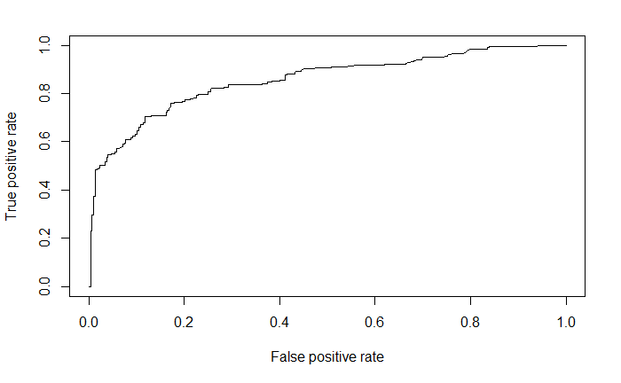

```r
result2<-predict(modellog,test,type="response")
pr<-prediction(result2,test$Survived)
prf<-performance(pr,measure="tpr",x.measure="fpr")
plot(prf)
```

```r
PredictSurvival<-function(inputdata,threshold)
{
  result<-predict(modellog,inputdata)
  result<-ifelse(result>threshold,1,0)
}
```

```r
print(PredictSurvival(test,0.5))
```

[output not shown]

```r
table(test$Survived,PredictSurvival(test,0.5))
```

```
      0   1
  0 271  26
  1  78 125
```

```r
table(test$Survived,PredictSurvival(test,0.75))
```

```
      0   1
  0 283  14
  1  92 111
```

#Caase where the logistic regresion model can fail

Logistic Regression only estimates a linear boundary. So, when there is non-linear separation of labels, Logistic regression will fail badly. If there are multiple “easy to classify” datapoints that are far away from the decision boundary, then they will distort the decision boundary which will make “wrong classifications” from datapoints that are quite close to the decision boundary. Which will in turn make the decision boundary non-linear and thus the model will get overtrained